# Select brain studies

Leonardo Collado-Torres

7/6/2017

# Required R packages

If you want to reproduce this document, you will need the following R packages installed. It’s best if you install R 3.5 from [CRAN](https://cran.r-project.org/) and maybe even [RStudio](https://www.rstudio.com/).

```r
## Install R 3.5
install.packages('BiocManager')
BiocManager::install(c('recount', 'downloader', 'devtools', 'DT'))
```

# Get the predictions data

First we load the R packages.

```r
library('recount')
library('downloader')
library('devtools')
library('DT')
```

Next we load the prediction data from Shannon Ellis which is stored in a data.frame (a table) called `PredictedPhenotypes`.

```r
## Load the predictions
predfile <- 'PredictedPhenotypes_v0.0.03.rda'
url <- paste0("https://github.com/leekgroup/recount-website/blob/master/predictions/",
    predfile, "?raw=true")
destfile <- file.path(tempdir(), predfile)
downloader::download(url, destfile = destfile, mode = "wb")
load(destfile)

## Explore the data a bit
head(PredictedPhenotypes)
```

```
##    sample_id dataset reported_sex predicted_sex accuracy_sex
## 1  SRR660824    gtex         male          male    0.9981128
## 2 SRR2166176    gtex         male          male    0.9981128
## 3  SRR606939    gtex       female        female    0.9981128
## 4 SRR2167642    gtex         male          male    0.9981128
## 5 SRR2165473    gtex         male          male    0.9981128
## 6  SRR603858    gtex         male          male    0.9981128
##   reported_samplesource predicted_samplesource accuracy_samplesource
## 1                tissue                 tissue              0.961732
## 2                tissue                 tissue              0.961732
## 3                tissue                 tissue              0.961732
## 4                tissue                 tissue              0.961732
## 5                tissue                 tissue              0.961732
## 6                tissue              cell_line              0.961732
##   reported_tissue predicted_tissue accuracy_tissue
```

[output cut: 20 more lines]

```r
dim(PredictedPhenotypes)
```

```
## [1] 70479    14
```

Now we can identify which of the 70k+ samples are predicted to be from the brain.

```r
brain <- tolower(PredictedPhenotypes$predicted_tissue) == 'brain'
length(brain)
```

```
## [1] 70479
```

```r
table(brain)
```

```
## brain
## FALSE  TRUE
## 60314  6199
```

# Match with SRA metadata

Using the `all_metadata()` function from `recount` we download the metadata for the roughly 50k samples from SRA.

```r
meta <- all_metadata()
```

```
## 2017-07-06 15:40:15 downloading the metadata to /var/folders/cx/n9s558kx6fb7jf5z_pgszgb80000gn/T//RtmpEc4716/metadata_clean_sra.Rdata
```

```r
dim(meta)
```

```
## [1] 50099    21
```

We can match the predicted brain samples to the SRA metadata using the `run` identifier. Since the metadata doesn’t include the roughly 20k samples from GTEx and TCGA, not all predicted brain samples match. That is ok because we want to focus on the SRA data for which we don’t have proper metadata.

```r
map <- match(PredictedPhenotypes$sample_id[brain], meta$run)
map <- map[!is.na(map)]

## Number of predicted brain samples in SRA
length(map)
```

```
## [1] 4601
```

```r
## Number of corresponding studies in SRA with at least 1 predicted brain sample
length(unique(meta$project[map]))
```

```
## [1] 363
```

Now we can get the project ids and check what percent of the samples for a given project have predicted brain samples.

```r
proj <- meta$project[map]
proj.n <- table(proj)

## Get the total number of samples in the projects
proj.all <- table(meta$project)
map.proj <- match(names(proj.n), names(proj.all))
proj.all <- proj.all[map.proj]

## Drop projects with less than 4 samples
table(proj.all >= 4)
```

```
##
## FALSE  TRUE
##    37   326
```

```r
proj.n <- proj.n[proj.all >= 4]
proj.all <- proj.all[proj.all >= 4]

## Calculate the percent of predicted brain samples
proj.perc <- as.vector(round(proj.n / proj.all * 100, 2))

## Explore that distribution
summary(proj.perc)
```

```
##    Min. 1st Qu.  Median    Mean 3rd Qu.    Max.
##    0.15    5.88   18.30   33.79   59.58  100.00
```

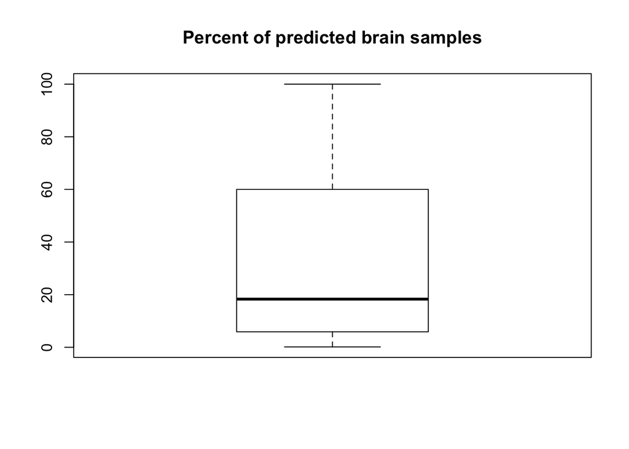

```r
boxplot(proj.perc, main = 'Percent of predicted brain samples')
```

# Selected projects

To reduce false positives brain predictions, we will focus on studies that are mostly brain samples.

```r
cutoffs <- c(70, 80, 90)
cutoffs.pass <- sapply(cutoffs, function(cut) { table(proj.perc > cut) })
colnames(cutoffs.pass) <- cutoffs
cutoffs.pass
```

```
##        70  80  90
## FALSE 259 267 275
## TRUE   67  59  51
```

We can then put all the information in a single table, export it to a text file, and explore it interactively in this document.

```r
proj.df <- data.frame(brain_predicted_n = as.vector(proj.n), project_n = as.vector(proj.all),
    brain_percent = proj.perc, project_id = names(proj.n))
proj.df <- proj.df[order(proj.df$brain_percent, decreasing = TRUE), ]

write.table(proj.df, file = 'projects_list.txt', sep = '\t', col.names = TRUE, quote = FALSE, row.names = FALSE)

datatable(proj.df,
    options = list(pagingType='full_numbers', pageLength=25, scrollX='100%'),
    escape = FALSE, rownames = FALSE)
```

| brain_predicted_n | project_n | brain_percent | project_id |
| --- | --- | --- | --- |
| 18 | 18 | 100 | ERP001304 |
| 6 | 6 | 100 | SRP002274 |
| 12 | 12 | 100 | SRP007483 |
| 4 | 4 | 100 | SRP017809 |
| 25 | 25 | 100 | SRP017933 |
| 14 | 14 | 100 | SRP019762 |
| 4 | 4 | 100 | SRP020661 |
| 5 | 5 | 100 | SRP021924 |
| 16 | 16 | 100 | SRP026048 |
| 38 | 38 | 100 | SRP030628 |

[output cut: 316 more lines]

# Data to use

Lets focus on the projects where at least 70 percent of the samples are predicted to come from the brain. That would include project `SRP025982` which from https://trace.ncbi.nlm.nih.gov/Traces/study/?acc=SRP025982 is mostly “universal human brain”.

# Reproducibility information

```r
## Reproducibility information
print('Reproducibility information:')
```

```
## [1] "Reproducibility information:"
```

```r
Sys.time()
```

```
## [1] "2017-07-06 15:40:18 EDT"
```

```r
proc.time()
```

```
##    user  system elapsed
##  11.375   0.756  16.828
```

```r
options(width = 120)
```

[output not shown]

```
## Packages --------------------------------------------------------------------------------------------------------------
```

```
##  package              * version  date       source
##  acepack                1.4.1    2016-10-29 CRAN (R 3.4.0)
##  AnnotationDbi          1.38.1   2017-06-01 Bioconductor
##  backports              1.1.0    2017-05-22 CRAN (R 3.4.0)
##  base                 * 3.4.0    2017-04-21 local
##  base64enc              0.1-3    2015-07-28 CRAN (R 3.4.0)
##  Biobase              * 2.36.2   2017-05-04 Bioconductor
##  BiocGenerics         * 0.22.0   2017-04-25 Bioconductor
##  BiocParallel           1.10.1   2017-05-03 Bioconductor
##  biomaRt                2.32.1   2017-06-09 Bioconductor
##  Biostrings             2.44.1   2017-06-01 Bioconductor
##  bit                    1.1-12   2014-04-09 CRAN (R 3.4.0)
##  bit64                  0.9-7    2017-05-08 CRAN (R 3.4.0)
##  bitops                 1.0-6    2013-08-17 CRAN (R 3.4.0)
##  blob                   1.1.0    2017-06-17 CRAN (R 3.4.0)
##  BSgenome               1.44.0   2017-04-25 Bioconductor
##  bumphunter             1.17.2   2017-05-09 Bioconductor
##  checkmate              1.8.2    2016-11-02 CRAN (R 3.4.0)
##  cluster                2.0.6    2017-03-10 CRAN (R 3.4.0)
##  codetools              0.2-15   2016-10-05 CRAN (R 3.4.0)
##  colorspace             1.3-2    2016-12-14 CRAN (R 3.4.0)
##  compiler               3.4.0    2017-04-21 local
##  data.table             1.10.4   2017-02-01 CRAN (R 3.4.0)
##  datasets             * 3.4.0    2017-04-21 local
##  DBI                    0.7      2017-06-18 CRAN (R 3.4.0)
##  DelayedArray         * 0.2.7    2017-06-03 Bioconductor
##  derfinder              1.10.4   2017-05-11 Bioconductor
##  derfinderHelper        1.10.0   2017-04-25 Bioconductor
##  devtools             * 1.13.2   2017-06-02 CRAN (R 3.4.0)
##  digest                 0.6.12   2017-01-27 CRAN (R 3.4.0)
##  doRNG                  1.6.6    2017-04-10 CRAN (R 3.4.0)
##  downloader           * 0.4      2015-07-09 CRAN (R 3.4.0)
##  DT                   * 0.2      2016-08-09 CRAN (R 3.4.0)
##  evaluate               0.10     2016-10-11 CRAN (R 3.4.0)
##  foreach                1.4.3    2015-10-13 CRAN (R 3.4.0)
##  foreign                0.8-69   2017-06-21 CRAN (R 3.4.0)
##  Formula                1.2-1    2015-04-07 CRAN (R 3.4.0)
##  GenomeInfoDb         * 1.12.2   2017-06-09 Bioconductor
##  GenomeInfoDbData       0.99.0   2017-02-14 Bioconductor
##  GenomicAlignments      1.12.1   2017-05-12 Bioconductor
```

[output cut: 54 more lines]

```
##  stats4               * 3.4.0    2017-04-21 local
##  stringi                1.1.5    2017-04-07 CRAN (R 3.4.0)
##  stringr                1.2.0    2017-02-18 CRAN (R 3.4.0)
##  SummarizedExperiment * 1.6.3    2017-05-29 Bioconductor
##  survival               2.41-3   2017-04-04 CRAN (R 3.4.0)
##  tibble                 1.3.3    2017-05-28 CRAN (R 3.4.0)
##  tools                  3.4.0    2017-04-21 local
##  utils                * 3.4.0    2017-04-21 local
##  VariantAnnotation      1.22.2   2017-06-22 Bioconductor
##  withr                  1.0.2    2016-06-20 CRAN (R 3.4.0)
##  XML                    3.98-1.9 2017-06-19 CRAN (R 3.4.0)
##  xtable                 1.8-2    2016-02-05 CRAN (R 3.4.0)
##  XVector                0.16.0   2017-04-25 Bioconductor
##  yaml                   2.1.14   2016-11-12 CRAN (R 3.4.0)
##  zlibbioc               1.22.0   2017-04-25 Bioconductor
```